# Random Forest and GBM Vignette

Jeremy Werner

2019-04-07

Tree-based models are amazing. Here’s a very simple vignette demonstrating how to use Artisanal Machine Learning’s Random Forest and GBM models.

# Read Abalone Data

```r
library(ArtisanalMachineLearning)
```

This example will be using the ‘Abalone’ dataset that I robbed from the internet here: https://archive.ics.uci.edu/ml/datasets/abalone where we try to predict the age of abalones from measured characteristics.

```r
dim(abalone_data$data)
```

```
## [1] 4177    8
```

```r
summary(abalone_data$data)
```

```
##       sex            length         diameter          height
##  Min.   :1.000   Min.   :0.075   Min.   :0.0550   Min.   :0.0000
##  1st Qu.:1.000   1st Qu.:0.450   1st Qu.:0.3500   1st Qu.:0.1150
##  Median :2.000   Median :0.545   Median :0.4250   Median :0.1400
##  Mean   :2.053   Mean   :0.524   Mean   :0.4079   Mean   :0.1395
##  3rd Qu.:3.000   3rd Qu.:0.615   3rd Qu.:0.4800   3rd Qu.:0.1650
##  Max.   :3.000   Max.   :0.815   Max.   :0.6500   Max.   :1.1300
##     weight.w         weight.s         weight.v        weight.sh
##  Min.   :0.0020   Min.   :0.0010   Min.   :0.0005   Min.   :0.0015
##  1st Qu.:0.4415   1st Qu.:0.1860   1st Qu.:0.0935   1st Qu.:0.1300
##  Median :0.7995   Median :0.3360   Median :0.1710   Median :0.2340
##  Mean   :0.8287   Mean   :0.3594   Mean   :0.1806   Mean   :0.2388
##  3rd Qu.:1.1530   3rd Qu.:0.5020   3rd Qu.:0.2530   3rd Qu.:0.3290
##  Max.   :2.8255   Max.   :1.4880   Max.   :0.7600   Max.   :1.0050
```

The semi-large data set has many numeric columns and a numeric response that takes integer values from 1-29.

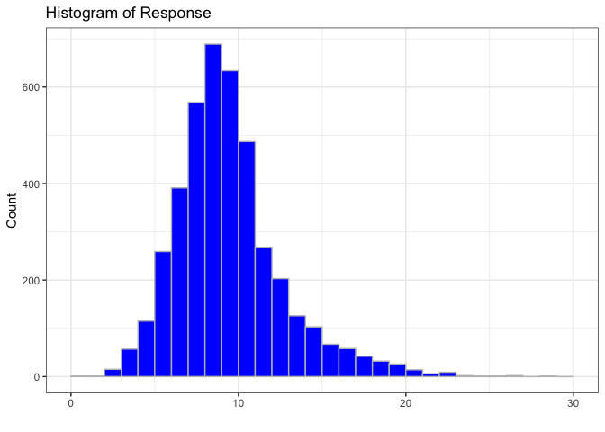

# Random Forest Model

```r
random_forest = aml_random_forest(data=abalone_data$data,
                                  response=abalone_data$response,
                                  b=200,
                                  m=6,
                                  evaluation_criterion=sum_of_squares,
                                  min_obs=5,
                                  max_depth=16,
                                  verbose=FALSE)
```

Now that we have a random forest model, let’s simply verify that it’s fitting a better-than-garbage model on the training data.

```r
random_forest_predictions = predict_all(random_forest, abalone_data$data, n_trees=200)
```

## SSE on training data

```r
sum((abalone_data$response - random_forest_predictions)^2) / length(abalone_data$response)
```

```
## [1] 3.235341
```

## Comparison of predicted and actual for Random Forest

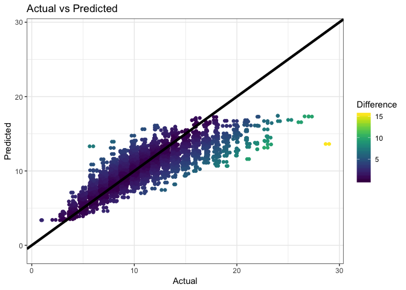

Not bad! This model is clearly picking up some signal. Let’s try out a small GBM now just for kicks.

# GBM Model

```r
gbm = aml_gbm(abalone_data$data,
              abalone_data$response,
              learning_rate=.1,
              n_trees=50,
              evaluation_criterion=sum_of_squares,
              min_obs=10,
              max_depth=4,
              verbose=FALSE)
```

Circa the RF model, let’s see if this picks up any signal at all on the training data.

```r
gbm_predictions = predict_all(gbm, abalone_data$data, n_trees=50)
```

## SSE on training data

```r
sum((abalone_data$response - gbm_predictions)^2) / length(abalone_data$response)
```

```
## [1] 7.357425
```

## Comparison of predicted and actual for GBM

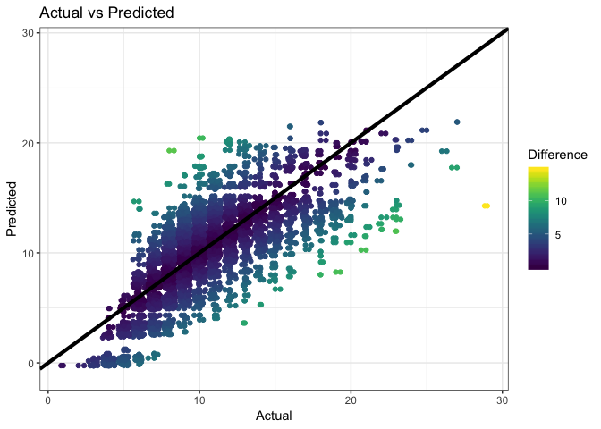

# Conclusion

The RF model is outperforming the GBM, but the GBM is significantly smaller and the author didn’t spend much time tuning the hyperparameters ¯_(ツ)_/¯

Also, this illustration only includes looking at statistics on the training data set, so we definitely can’t make huge conclusions. The author simply wanted to demonstrate these hand-crafted models were producing better-than-trash results, and that has been achieved.